# Gene set enrichment analysis

Go over GSEA with examples

Author

Nicholas Harbour

Published

November 28, 2024, 12:50:35

Modified

November 28, 2024, 12:49:36

## 1 Gene set enrichment analysis

Let’s use a real example https://www.ncbi.nlm.nih.gov/geo/query/acc.cgi?acc=GSE197576

How to download the files from ftp https://www.ncbi.nlm.nih.gov/geo/info/download.html

https://ftp.ncbi.nlm.nih.gov/geo/series/GSE197nnn/GSE197576/suppl/

Alternative use GEOquery https://bioconductor.org/packages/release/bioc/html/GEOquery.html

```bash
curl -O https://ftp.ncbi.nlm.nih.gov/geo/series/GSE197nnn/GSE197576/suppl/GSE197576_raw_gene_counts_matrix.tsv.gz

csvtk pretty -t  GSE197576_raw_gene_counts_matrix.tsv.gz | less -S

csvtk headers -t   GSE197576_raw_gene_counts_matrix.tsv.gz

csvtk cut -t -f1,2,3,12,13 GSE197576_raw_gene_counts_matrix.tsv.gz| head

csvtk cut -t -f1,2,3,12,13 GSE197576_raw_gene_counts_matrix.tsv.gz > raw_counts.tsv
```

Get csvtk at https://github.com/shenwei356/csvtk

### 1.1 read the data into R and make a DESeq2 object

follow the tutorial http://bioconductor.org/packages/devel/bioc/vignettes/DESeq2/inst/doc/DESeq2.html

```r
library(dplyr)
library(readr)
library(here)
library(DESeq2)
raw_counts<- read_tsv("raw_counts.tsv")
raw_counts_mat<- raw_counts[, -1] %>% as.matrix

#head(raw_counts_mat)

rownames(raw_counts_mat)<- raw_counts$gene
head(raw_counts_mat)
```

```
            01_SW_sgCTRL_Norm 02_SW_sgCTRL_Norm 17_SW_sgRELB_3_Hyp
DDX11L1                     0                 0                  0
WASH7P                     18                11                 30
MIR6859-1                   5                 1                  8
MIR1302-2HG                 0                 0                  0
MIR1302-2                   0                 0                  0
FAM138A                     0                 0                  0
            18_SW_sgRELB_3_Hyp
DDX11L1                      0
WASH7P                      25
MIR6859-1                    5
MIR1302-2HG                  0
MIR1302-2                    0
FAM138A                      0
```

Make a sample sheet

```r
coldata<- data.frame(condition = c("normoxia", "normoxia", "hypoxia", "hypoxia"))

rownames(coldata)<- colnames(raw_counts_mat)

coldata
```

```
                   condition
01_SW_sgCTRL_Norm   normoxia
02_SW_sgCTRL_Norm   normoxia
17_SW_sgRELB_3_Hyp   hypoxia
18_SW_sgRELB_3_Hyp   hypoxia
```

Make a DEseq2 object

```r
all(rownames(coldata) == colnames(raw_counts_mat))
```

```
[1] TRUE
```

```r
dds <- DESeqDataSetFromMatrix(countData = raw_counts_mat,
                              colData = coldata,
                              design = ~ condition)
dds <- DESeq(dds)
res <- results(dds, contrast = c("condition", "hypoxia", "normoxia"))

res %>%
  as.data.frame() %>%
  arrange((padj), desc(log2FoldChange)) %>%
  head(n=30)
```

```
           baseMean log2FoldChange      lfcSE      stat        pvalue
IGFBP3    17627.045       4.874526 0.05105322  95.47931  0.000000e+00
CCN2       1961.433       3.438440 0.08952079  38.40940  0.000000e+00
NTRK2      1970.864       3.302292 0.08575203  38.50978  0.000000e+00
PSG1       2268.870       3.113563 0.07961448  39.10799  0.000000e+00
BMP4       6384.970       2.876704 0.05509665  52.21195  0.000000e+00
NR2F1      2437.826       2.834013 0.07424802  38.16954  0.000000e+00
NGFR       6558.202       2.571374 0.05775810  44.51971  0.000000e+00
GABARAPL1  6203.505       2.546365 0.05234969  48.64145  0.000000e+00
PPME1     16084.573       2.431951 0.03998917  60.81525  0.000000e+00
TRIB2      4239.508       2.287041 0.05782297  39.55246  0.000000e+00
BNIP3L     6702.106       2.174482 0.04869402  44.65605  0.000000e+00
PGK1      37685.088       2.072081 0.03569239  58.05385  0.000000e+00
PHLDB2     9231.784       1.908146 0.04463449  42.75048  0.000000e+00
CRIM1      7288.741       1.833228 0.04731158  38.74799  0.000000e+00
TMSB4X     9508.268       1.779633 0.04563041  39.00103  0.000000e+00
SLC2A3    55944.808       1.454729 0.03345849  43.47864  0.000000e+00
NOLC1      7878.359      -1.743002 0.04476146 -38.93979  0.000000e+00
MT2A      16166.488      -1.870772 0.04540899 -41.19827  0.000000e+00
EPAS1     20565.552      -2.718551 0.04024780 -67.54533  0.000000e+00
CHI3L1     2592.054      -2.918265 0.06954657 -41.96131  0.000000e+00
UCP2       3489.101       2.650692 0.07134508  37.15311 3.905058e-302
DKK4       7264.301     -10.290468 0.27742235 -37.09315 3.623309e-301
H2BC12     4410.896      -2.057889 0.05743737 -35.82841 3.990017e-281
HSPD1     23887.790      -1.322897 0.03736480 -35.40489 1.435610e-274
IGFL2      2491.296       2.466703 0.07120895  34.64035 6.242866e-263
HEG1       5450.390       1.870342 0.05486804  34.08801 1.110391e-254
NPM1      29007.495      -1.184459 0.03517489 -33.67342 1.416420e-248
CCN1       3015.239       2.133673 0.06451354  33.07326 7.204165e-240
ANO1       7586.398      -1.636257 0.04953317 -33.03357 2.678147e-239
BHLHE40    4958.569       1.799527 0.05541353  32.47451 2.442654e-231
                   padj
IGFBP3     0.000000e+00
CCN2       0.000000e+00
NTRK2      0.000000e+00
PSG1       0.000000e+00
BMP4       0.000000e+00
NR2F1      0.000000e+00
NGFR       0.000000e+00
GABARAPL1  0.000000e+00
PPME1      0.000000e+00
TRIB2      0.000000e+00
BNIP3L     0.000000e+00
PGK1       0.000000e+00
PHLDB2     0.000000e+00
CRIM1      0.000000e+00
TMSB4X     0.000000e+00
SLC2A3     0.000000e+00
NOLC1      0.000000e+00
MT2A       0.000000e+00
EPAS1      0.000000e+00
CHI3L1     0.000000e+00
UCP2      3.386987e-299
DKK4      2.999771e-298
H2BC12    3.159746e-278
HSPD1     1.089508e-271
IGFL2     4.548303e-260
HEG1      7.778713e-252
NPM1      9.555066e-246
CCN1      4.686309e-237
ANO1      1.682061e-236
BHLHE40   1.483017e-228
```

```r
# arbritrary selection of significant genes
significant_genes<- res %>%
  as.data.frame() %>%
  filter(padj <=0.01, abs(log2FoldChange) >= 2) %>%
  rownames()


significant_genes
```

```
  [1] "LOC729737"         "LOC107985728"      "LOC107985376"
  [4] "PADI2"             "ALPL"              "LOC105376863"
  [7] "SYNC"              "GJB4"              "COL8A2"
 [10] "POU3F1"            "KCNQ4"             "EDN2"
 [13] "HPDL"              "LDLRAD1"           "KANK4"
 [16] "AK5"               "LOC107985054"      "CCN1"
 [19] "LRRC8B"            "PLPPR4"            "NBPF6"
 [22] "ELAPOR1"           "PROK1"             "KCND3"
 [25] "LINC01750"         "OLFML3"            "HMGCS2"
 [28] "ADAMTSL4"          "FLG"               "FLG-AS1"
 [31] "MUC1"              "SH2D2A"            "FCRL5"
 [34] "VANGL2"            "FCGR2A"            "LOC107985452"
 [37] "PAPPA2"            "CACNA1E"           "LOC107985232"
 [40] "HMCN1"             "LHX9"              "KIF21B"
 [43] "TNNT2"             "LMOD1"             "LOC101929388"
```

[output cut: 193 more lines]

## 2 pathway analysis

https://yulab-smu.top/biomedical-knowledge-mining-book/enrichment-overview.html

### 2.1 over-representation test

```r
library(clusterProfiler)
library(org.Hs.eg.db)
#convert gene symbol to Entrez ID for

significant_genes_map<- clusterProfiler::bitr(geneID = significant_genes,
                      fromType="SYMBOL", toType="ENTREZID",
                      OrgDb="org.Hs.eg.db")
head(significant_genes_map)
```

```
        SYMBOL  ENTREZID
1    LOC729737    729737
2 LOC107985728 107985728
4        PADI2     11240
5         ALPL       249
6 LOC105376863 105376863
7         SYNC     81493
```

```r
## background genes are genes that are detected in the RNAseq experiment
background_genes<- res %>%
  as.data.frame() %>%
  filter(baseMean != 0) %>%
  tibble::rownames_to_column(var = "gene") %>%
  pull(gene)


res_df<- res %>%
  as.data.frame() %>%
  filter(baseMean != 0) %>%
  tibble::rownames_to_column(var = "gene")

background_genes_map<- bitr(geneID = background_genes,
                            fromType="SYMBOL",
                            toType="ENTREZID",
                      OrgDb="org.Hs.eg.db")
```

GO term enrichment

Gene Ontology(GO) defines concepts/classes used to describe gene function, and relationships between these concepts. It classifies functions along three aspects:

MF: Molecular Function molecular activities of gene products

CC: Cellular Component where gene products are active

BP: Biological Process pathways and larger processes made up of the activities of multiple gene products

GO terms are organized in a directed acyclic graph, where edges between terms represent parent-child relationship.

```r
ego <- enrichGO(gene          = significant_genes_map$ENTREZID,
                universe      = background_genes_map$ENTREZID,
                OrgDb         = org.Hs.eg.db,
                ont           = "BP",
                pAdjustMethod = "BH",
                pvalueCutoff  = 0.01,
                qvalueCutoff  = 0.05,
                readable      = TRUE)
head(ego)
```

```
                   ID                         Description GeneRatio   BgRatio
GO:0051384 GO:0051384          response to glucocorticoid    16/439 117/14875
GO:0031960 GO:0031960          response to corticosteroid    17/439 135/14875
GO:0040013 GO:0040013   negative regulation of locomotion    25/439 296/14875
GO:0001666 GO:0001666                 response to hypoxia    24/439 278/14875
GO:0036293 GO:0036293 response to decreased oxygen levels    24/439 290/14875
GO:0070482 GO:0070482           response to oxygen levels    25/439 312/14875
           RichFactor FoldEnrichment   zScore       pvalue     p.adjust
GO:0051384 0.13675214       4.633686 6.880963 3.300843e-07 0.0009277357
GO:0031960 0.12592593       4.266852 6.649215 4.733345e-07 0.0009277357
GO:0040013 0.08445946       2.861810 5.642090 2.459981e-06 0.0026192601
GO:0001666 0.08633094       2.925222 5.650596 2.672714e-06 0.0026192601
GO:0036293 0.08275862       2.804179 5.410633 5.552093e-06 0.0040951295
GO:0070482 0.08012821       2.715050 5.338896 6.268055e-06 0.0040951295
                 qvalue
GO:0051384 0.0008340653
GO:0031960 0.0008340653
GO:0040013 0.0023548021
GO:0001666 0.0023548021
GO:0036293 0.0036816578
GO:0070482 0.0036816578
                                                                                                                                                               geneID
GO:0051384                                                                   ALPL/HMGCS2/CPS1/PCSK1/BMP6/EDN1/STC1/ANXA1/PAPPA/DDIT4/UCP2/UCP3/GJB2/HSD11B2/BCL2/MAOB
GO:0031960                                                             ALPL/HMGCS2/CPS1/PCSK1/BMP6/EDN1/INHBA/STC1/ANXA1/PAPPA/DDIT4/UCP2/UCP3/GJB2/HSD11B2/BCL2/MAOB
GO:0040013 PADI2/IL24/IGFBP5/SRGAP3/SEMA3F/SEMA5A/ARRDC3/NEDD9/IGFBP3/STC1/KLF4/LRP1/SRGAP1/NAV3/DACH1/NKX2-1/BMP4/SEMA6D/CDH11/ALOX15B/NGFR/CYGB/LDLRAD4/BCL2/GPR173
GO:0001666                      KCNK3/EPAS1/SOD3/NDNF/EDN1/TREM2/CD24/INHBA/CAV1/STC1/BNIP3L/CA9/DDIT4/UCP2/UCP3/CRYAB/EGLN3/MMP2/HSD11B2/NOS2/CYGB/BCL2/ANGPTL4/PGK1
GO:0036293                      KCNK3/EPAS1/SOD3/NDNF/EDN1/TREM2/CD24/INHBA/CAV1/STC1/BNIP3L/CA9/DDIT4/UCP2/UCP3/CRYAB/EGLN3/MMP2/HSD11B2/NOS2/CYGB/BCL2/ANGPTL4/PGK1
GO:0070482               KCNK3/EPAS1/SOD3/NDNF/EDN1/TREM2/CD24/INHBA/CAV1/STC1/BNIP3L/CA9/DDIT4/UCP2/UCP3/CRYAB/EGLN3/MMP2/HSD11B2/NOS2/COL1A1/CYGB/BCL2/ANGPTL4/PGK1
           Count
GO:0051384    16
GO:0031960    17
GO:0040013    25
GO:0001666    24
GO:0036293    24
GO:0070482    25
```

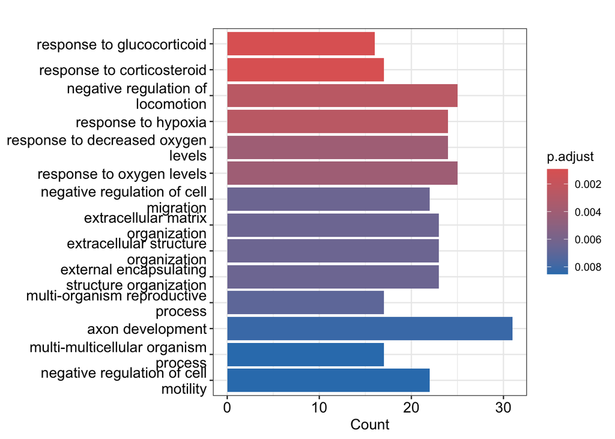

```r
library(enrichplot)
barplot(ego, showCategory=20)
```

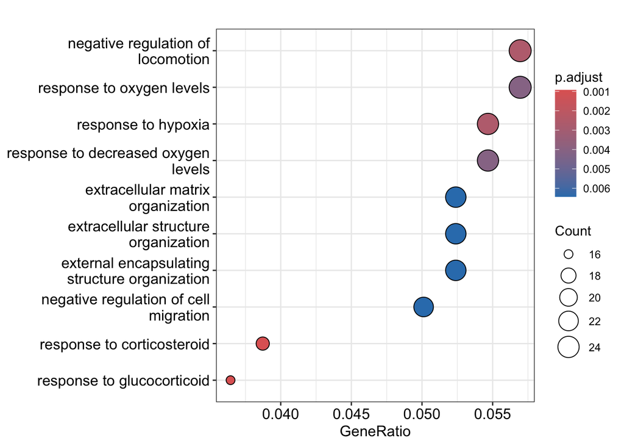

```r
dotplot(ego)
```

H: hallmark gene sets C1: positional gene sets C2: curated gene sets C3: motif gene sets C4: computational gene sets C5: GO gene sets C6: oncogenic signatures C7: immunologic signatures

```r
# install.packages("msigdbr")
library(msigdbr)

m_df <- msigdbr(species = "Homo sapiens")
head(m_df)
```

```
# A tibble: 6 × 15
  gs_cat gs_subcat      gs_name        gene_symbol entrez_gene ensembl_gene
  <chr>  <chr>          <chr>          <chr>             <int> <chr>
1 C3     MIR:MIR_Legacy AAACCAC_MIR140 ABCC4             10257 ENSG00000125257
2 C3     MIR:MIR_Legacy AAACCAC_MIR140 ABRAXAS2          23172 ENSG00000165660
3 C3     MIR:MIR_Legacy AAACCAC_MIR140 ACTN4                81 ENSG00000130402
4 C3     MIR:MIR_Legacy AAACCAC_MIR140 ACTN4                81 ENSG00000282844
5 C3     MIR:MIR_Legacy AAACCAC_MIR140 ACVR1                90 ENSG00000115170
6 C3     MIR:MIR_Legacy AAACCAC_MIR140 ADAM9              8754 ENSG00000168615
# ℹ 9 more variables: human_gene_symbol <chr>, human_entrez_gene <int>,
#   human_ensembl_gene <chr>, gs_id <chr>, gs_pmid <chr>, gs_geoid <chr>,
#   gs_exact_source <chr>, gs_url <chr>, gs_description <chr>
```

```r
m_t2g <- msigdbr(species = "Homo sapiens", category = "H") %>%
  dplyr::select(gs_name, entrez_gene)


table(m_t2g$gs_name)
```

```
                     HALLMARK_ADIPOGENESIS
                                       210
              HALLMARK_ALLOGRAFT_REJECTION
                                       335
                HALLMARK_ANDROGEN_RESPONSE
                                       102
                     HALLMARK_ANGIOGENESIS
                                        36
                  HALLMARK_APICAL_JUNCTION
                                       231
                   HALLMARK_APICAL_SURFACE
                                        46
                        HALLMARK_APOPTOSIS
                                       183
             HALLMARK_BILE_ACID_METABOLISM
                                       114
          HALLMARK_CHOLESTEROL_HOMEOSTASIS
                                        77
                      HALLMARK_COAGULATION
                                       162
                       HALLMARK_COMPLEMENT
                                       237
                       HALLMARK_DNA_REPAIR
                                       170
                      HALLMARK_E2F_TARGETS
                                       218
HALLMARK_EPITHELIAL_MESENCHYMAL_TRANSITION
                                       204
          HALLMARK_ESTROGEN_RESPONSE_EARLY
                                       216
           HALLMARK_ESTROGEN_RESPONSE_LATE
                                       218
            HALLMARK_FATTY_ACID_METABOLISM
                                       165
                   HALLMARK_G2M_CHECKPOINT
                                       204
                       HALLMARK_GLYCOLYSIS
                                       215
               HALLMARK_HEDGEHOG_SIGNALING
                                        36
```

[output cut: 45 more lines]

```
                                       144
               HALLMARK_TGF_BETA_SIGNALING
                                        59
          HALLMARK_TNFA_SIGNALING_VIA_NFKB
                                       228
        HALLMARK_UNFOLDED_PROTEIN_RESPONSE
                                       115
                   HALLMARK_UV_RESPONSE_DN
                                       152
                   HALLMARK_UV_RESPONSE_UP
                                       191
       HALLMARK_WNT_BETA_CATENIN_SIGNALING
                                        50
            HALLMARK_XENOBIOTIC_METABOLISM
                                       224
```

```r
head(m_t2g)
```

```
# A tibble: 6 × 2
  gs_name               entrez_gene
  <chr>                       <int>
1 HALLMARK_ADIPOGENESIS          19
2 HALLMARK_ADIPOGENESIS       11194
3 HALLMARK_ADIPOGENESIS       10449
4 HALLMARK_ADIPOGENESIS          33
5 HALLMARK_ADIPOGENESIS          34
6 HALLMARK_ADIPOGENESIS          35
```

```r
em <- enricher(significant_genes_map$ENTREZID, TERM2GENE=m_t2g,
               universe = background_genes_map$ENTREZID )
head(em)
```

```
                                                                                   ID
HALLMARK_KRAS_SIGNALING_DN                                 HALLMARK_KRAS_SIGNALING_DN
HALLMARK_HYPOXIA                                                     HALLMARK_HYPOXIA
HALLMARK_KRAS_SIGNALING_UP                                 HALLMARK_KRAS_SIGNALING_UP
HALLMARK_EPITHELIAL_MESENCHYMAL_TRANSITION HALLMARK_EPITHELIAL_MESENCHYMAL_TRANSITION
                                                                          Description
HALLMARK_KRAS_SIGNALING_DN                                 HALLMARK_KRAS_SIGNALING_DN
HALLMARK_HYPOXIA                                                     HALLMARK_HYPOXIA
HALLMARK_KRAS_SIGNALING_UP                                 HALLMARK_KRAS_SIGNALING_UP
HALLMARK_EPITHELIAL_MESENCHYMAL_TRANSITION HALLMARK_EPITHELIAL_MESENCHYMAL_TRANSITION
                                           GeneRatio  BgRatio RichFactor
HALLMARK_KRAS_SIGNALING_DN                    15/135 153/3988 0.09803922
HALLMARK_HYPOXIA                              17/135 192/3988 0.08854167
HALLMARK_KRAS_SIGNALING_UP                    16/135 175/3988 0.09142857
HALLMARK_EPITHELIAL_MESENCHYMAL_TRANSITION    16/135 182/3988 0.08791209
                                           FoldEnrichment   zScore       pvalue
HALLMARK_KRAS_SIGNALING_DN                       2.896151 4.476375 0.0001647937
HALLMARK_HYPOXIA                                 2.615586 4.294456 0.0002095112
HALLMARK_KRAS_SIGNALING_UP                       2.700868 4.306720 0.0002250273
HALLMARK_EPITHELIAL_MESENCHYMAL_TRANSITION       2.596988 4.127561 0.0003536209
                                              p.adjust      qvalue
HALLMARK_KRAS_SIGNALING_DN                 0.003450418 0.003158278
HALLMARK_HYPOXIA                           0.003450418 0.003158278
HALLMARK_KRAS_SIGNALING_UP                 0.003450418 0.003158278
HALLMARK_EPITHELIAL_MESENCHYMAL_TRANSITION 0.004066640 0.003722325
                                                                                                                         geneID
HALLMARK_KRAS_SIGNALING_DN                  1907/3699/11346/57451/1906/3955/105375355/56154/3851/3291/51168/3780/3750/778/55190
HALLMARK_HYPOXIA                           1907/3491/8497/57007/55076/901/1490/3484/3486/857/6781/665/1289/54541/596/51129/5230
HALLMARK_KRAS_SIGNALING_UP                   7139/3290/28951/2591/1437/639/10457/3624/3486/9314/51129/5121/3689/27344/3561/2556
HALLMARK_EPITHELIAL_MESENCHYMAL_TRANSITION  1296/3491/4148/5159/1490/3624/3486/6591/115908/1289/50863/4035/4313/1009/1277/50509
                                           Count
HALLMARK_KRAS_SIGNALING_DN                    15
HALLMARK_HYPOXIA                              17
HALLMARK_KRAS_SIGNALING_UP                    16
HALLMARK_EPITHELIAL_MESENCHYMAL_TRANSITION    16
```

### 2.2 Gene set enrichment analysis

```r
## you need all the genes and pre-rank them by p-value
## rank all the genes by signed fold change * -log10pvalue.


res_df<- res_df %>%
  mutate(signed_rank_stats = sign(log2FoldChange) * -log10(pvalue)) %>%
  left_join(background_genes_map, by= c("gene" = "SYMBOL")) %>%
  arrange(desc(signed_rank_stats))



## change the inf to big numbers as it will cause errors
res_df<- res_df %>%
  mutate(negative_log10pvalue = -log10(pvalue)) %>%
  mutate(negative_log10pvalue = ifelse(is.infinite(negative_log10pvalue), 1000, negative_log10pvalue)) %>%
  mutate(signed_rank_stats = sign(log2FoldChange) * negative_log10pvalue)

gene_list<- res_df$signed_rank_stats

names(gene_list)<- res_df$ENTREZID

# Filter out NA values from gene_list
gene_list <- gene_list[!is.na(names(gene_list))]
# Filter out rows with NA in ENTREZID
res_df <- res_df %>% filter(!is.na(ENTREZID))

em2 <- GSEA(gene_list, TERM2GENE=m_t2g)
```

```
using 'fgsea' for GSEA analysis, please cite Korotkevich et al (2019).
```

```
preparing geneSet collections...
```

```
GSEA analysis...
```

```
leading edge analysis...
```

```
done...
```

```r
head(em2)
```

```
                                                                                   ID
HALLMARK_G2M_CHECKPOINT                                       HALLMARK_G2M_CHECKPOINT
HALLMARK_E2F_TARGETS                                             HALLMARK_E2F_TARGETS
HALLMARK_MYC_TARGETS_V1                                       HALLMARK_MYC_TARGETS_V1
HALLMARK_EPITHELIAL_MESENCHYMAL_TRANSITION HALLMARK_EPITHELIAL_MESENCHYMAL_TRANSITION
HALLMARK_MYC_TARGETS_V2                                       HALLMARK_MYC_TARGETS_V2
HALLMARK_HYPOXIA                                                     HALLMARK_HYPOXIA
                                                                          Description
HALLMARK_G2M_CHECKPOINT                                       HALLMARK_G2M_CHECKPOINT
HALLMARK_E2F_TARGETS                                             HALLMARK_E2F_TARGETS
HALLMARK_MYC_TARGETS_V1                                       HALLMARK_MYC_TARGETS_V1
HALLMARK_EPITHELIAL_MESENCHYMAL_TRANSITION HALLMARK_EPITHELIAL_MESENCHYMAL_TRANSITION
HALLMARK_MYC_TARGETS_V2                                       HALLMARK_MYC_TARGETS_V2
HALLMARK_HYPOXIA                                                     HALLMARK_HYPOXIA
                                           setSize enrichmentScore       NES
HALLMARK_G2M_CHECKPOINT                        198      -0.8575317 -1.828338
HALLMARK_E2F_TARGETS                           197      -0.8534431 -1.818831
HALLMARK_MYC_TARGETS_V1                        194      -0.8311224 -1.767944
HALLMARK_EPITHELIAL_MESENCHYMAL_TRANSITION     182       0.8410419  1.718004
HALLMARK_MYC_TARGETS_V2                         57      -0.8962797 -1.663822
HALLMARK_HYPOXIA                               192       0.8075706  1.655819
                                                 pvalue     p.adjust
HALLMARK_G2M_CHECKPOINT                    4.452143e-08 1.489291e-06
HALLMARK_E2F_TARGETS                       5.957166e-08 1.489291e-06
HALLMARK_MYC_TARGETS_V1                    8.793386e-07 1.465564e-05
HALLMARK_EPITHELIAL_MESENCHYMAL_TRANSITION 3.603189e-05 4.503986e-04
HALLMARK_MYC_TARGETS_V2                    8.758123e-05 8.758123e-04
HALLMARK_HYPOXIA                           5.320398e-04 4.433665e-03
                                                 qvalue rank
HALLMARK_G2M_CHECKPOINT                    1.097373e-06 1953
HALLMARK_E2F_TARGETS                       1.097373e-06 1897
HALLMARK_MYC_TARGETS_V1                    1.079889e-05 1236
HALLMARK_EPITHELIAL_MESENCHYMAL_TRANSITION 3.318727e-04 1000
HALLMARK_MYC_TARGETS_V2                    6.453353e-04 1174
HALLMARK_HYPOXIA                           3.266911e-03  763
                                                            leading_edge
HALLMARK_G2M_CHECKPOINT                    tags=55%, list=8%, signal=51%
HALLMARK_E2F_TARGETS                       tags=56%, list=8%, signal=52%
HALLMARK_MYC_TARGETS_V1                    tags=69%, list=5%, signal=65%
HALLMARK_EPITHELIAL_MESENCHYMAL_TRANSITION tags=28%, list=4%, signal=27%
HALLMARK_MYC_TARGETS_V2                    tags=79%, list=5%, signal=75%
HALLMARK_HYPOXIA                           tags=34%, list=3%, signal=34%
                                                                                                                                                                                                                                                                                                            …
HALLMARK_G2M_CHECKPOINT                                                                                                                                                      3837/6118/3091/990/10024/10721/9700/890/23594/10592/3161/213…
HALLMARK_E2F_TARGETS                                                                                                                                            11113/10714/3148/81611/9700/55143/23594/5982/3161/5558/5411/…
HALLMARK_MYC_TARGETS_V1                    6432/4830/4673/5887/3015/4085/65005/7965/7298/5984/4706/8662…
HALLMARK_EPITHELIAL_MESENCHYMAL_TRANSITION                                                                                                                                                                                                                                                                  …
HALLMARK_MYC_TARGETS_V2                                                                                                                                                                                                                                                                                     …
HALLMARK_HYPOXIA                                                                                                                                                                                                                                                                                            …
```

```r
em2@result %>% View()
```

### 2.3 visualization

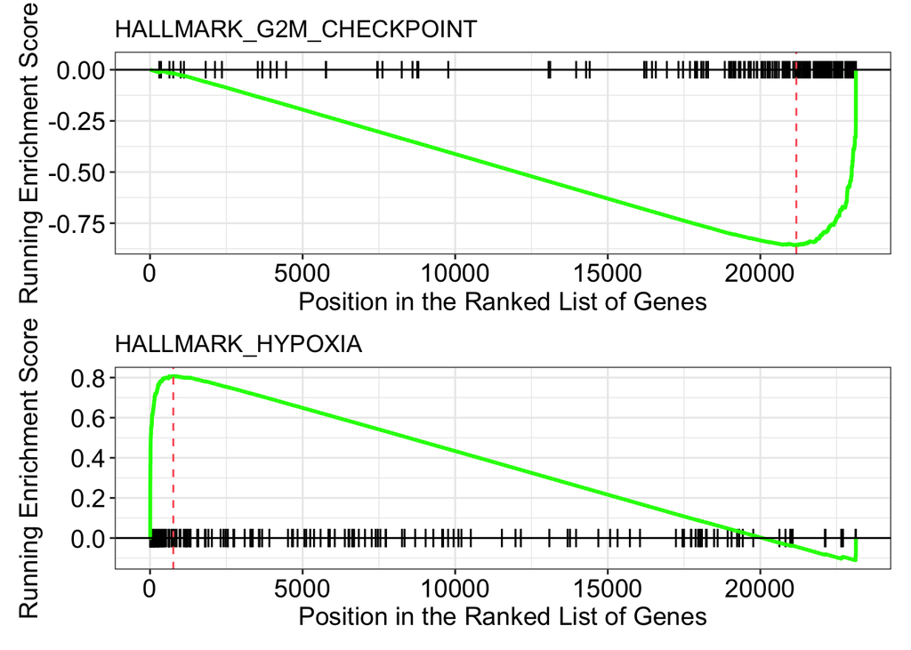

```r
p1<- gseaplot(em2, geneSetID = "HALLMARK_G2M_CHECKPOINT",
              by = "runningScore", title = "HALLMARK_G2M_CHECKPOINT")

p2 <- gseaplot(em2, geneSetID = "HALLMARK_HYPOXIA",
               by = "runningScore", title = "HALLMARK_HYPOXIA")

p1/p2
```